# RSV (ABRYSVO) - Device connection issue

OpenSourcePV

Data Lock Point: 2024_01_26

# 1 Quantitative Signal status

## 1.1 Disproportionality

The vaccine-event combination “RSV (ABRYSVO) - Device connection issue” was **a signal of disproportionate reporting** with an EB05 value of 19.74.

The threshold for being flagged as a signal of disproportionate reporting is an EB05>=2 meaning that there there is a 95% probability that the reporting of Device connection issue was at least twice post exposure to RSV (ABRYSVO) than post all vaccines [1]. Under the assumption of no causality between RSV (ABRYSVO) and Device connection issue and no bias it would have been expected to observe an EBGM of 1.

It means that the quantified causality criterion of strength of association is **met**.

*It is to be noted that the nature of the spontaneous report does not provide reliable estimates of the strength of association (whatever the choice of the disproportionality method) and that some reporting bias or difference in demographic characteristics might explain the (un)observed disproportion*.

## 1.2 Time-to-onset

The vaccine-event combination “RSV (ABRYSVO) - Device connection issue” was **not a signal of unexpected time-to-onset distribution** with a p-value of the two-sample Kolmogorov-Smirnov test being 1 and distance between the two empirical cumulative distributions being of 0%.

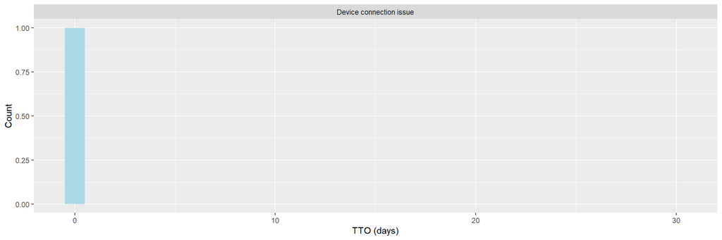

The TTO signal detection method tests if the distribution of Device connection issue post RSV (ABRYSVO) is significantly different from the distribution of Device connection issue post other vaccines using a two-sample Kolmogorov-Smirnov test [2]. The threshold for being flagged as a signal of unexpected time-to-onset distribution is a P-value <0.001 and a distance between the two empirical distributions larger than 20%. Under the assumption of no causality and no bias, it would have been expected that the time-to-onset distribution for “Device connection issue” would have been the same post RSV (ABRYSVO) than post other vaccines.

It means that the quantified causality criterion of temporality is **not met**.

*It is to be noted that the nature of the spontaneous report does not provide reliable estimates of the temporal relationship between the exposure and the occurrence of the events as there is the reporting bias over time: the latter the event occurs after exposure, the less chance it has to be reported. Other biases could distort the reported time-to-onset distribution (media attention, etc.)*

## 1.3 Overall

Based on the screening of the Empirical Bayes Geometric Mean (EBGM) and the screening of the time-to-onset distribution,the vaccine-event combination “RSV (ABRYSVO) - Device connection issue” is **considered as quantitative signal**.

# 2 Signal History

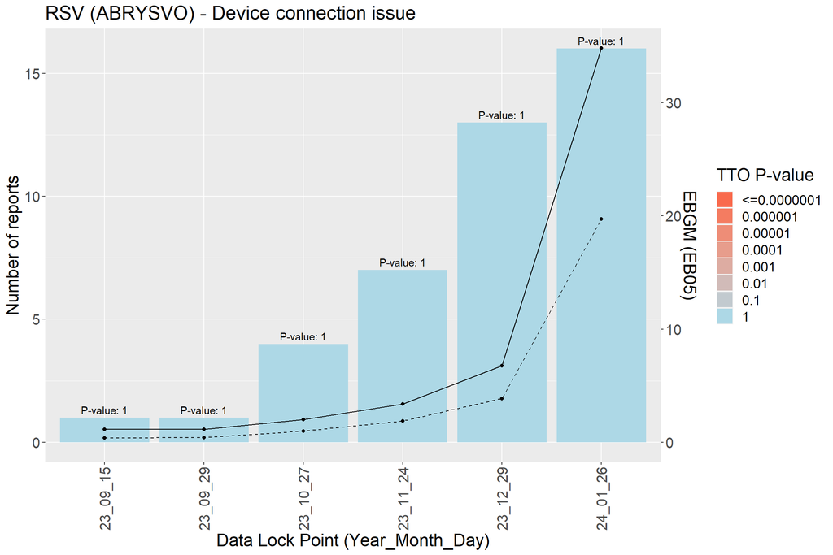

# 3 Case series

## 3.1 Seriousness

A total of 16 reports of Device connection issue were received post exposure to RSV (ABRYSVO). Among them:

- 0 (0.0 %) were fatal cases.
- 0 (0.0 %) were life threatening cases.
- 0 (0.0 %) were hospitalized cases.
- 0 (0.0 %) were emergency room cases.
- 0 (0.0 %) were cases with disabilies.

3 new cases were received since last data refresh.

## 3.2 Demographic characteristics

16 cases of Device connection issue post RSV (ABRYSVO) were reported in VAERS:

- Among them, there were 0 (0%) female cases and 2 (12.5%) male cases while the overall female:male ratio is 62:28%.
- The mean (median) age for patients presenting symptoms of Device connection issue was 75 (75) years while the overall mean (median) age was 69 (72) years.
- The top 5 contributing US states for patients presenting symptoms of Device connection issue were CA ( 18.8 %) , CO ( 12.5 %) , KS ( 12.5 %) , AZ ( 6.2 %) , KY ( 6.2 %) while overall the top 5 of contributing US states are NA ( 12.4 %) , CA ( 6.4 %) , NY ( 5.2 %) , OH ( 5.2 %) , PA ( 5 %)

# 4 Manufacturing

# 5 Listing of the cases

Narratives can be made visible clicking on the ⊕ symbol.

|  | VAERS ID | Sex/Age (Years) | Receipt Date | Seriousness status | List of symptoms | New | SYMPTOM_TEXT |
| --- | --- | --- | --- | --- | --- | --- | --- |
| &oplus; | 2729343 | U/NA | 01/02/2024 |  | Device connection issue | Yes | just gave you is the one that is defective Vial is damaged Plastic from the syringe barrel that one came off Plastic from the syringe barrel that one came off not able to screw on a new syringe to tha… |
| &oplus; | 2733025 | U/NA | 01/15/2024 |  | Device connection issue, Device leakage | Yes | tried to reconstitute 2 syringes and something went wrong when they were trying to reconstitute The initial case was missing the following minimum criteria no adverse effect Upon receipt of follow up … |
| &oplus; | 2733029 | U/NA | 01/15/2024 |  | Device connection issue, Syringe issue | Yes | two missed doses When she connects the two mechanisms it will create the burst or explode The initial case was missing the following minimum criteria no adverse effect Upon receipt of follow up inform… |
| &oplus; | 2679566 | U/NA | 09/06/2023 |  | Device connection issue | No | Abrysvo vaccine is defective could not insert the devices little plastic pieces came out from the device Due to unable to insertion for syringes I had to destroy 2 shots This is a spontaneous report r… |
| &oplus; | 2691544 | U/NA | 10/05/2023 |  | Device connection issue, Device leakage, Product leakage, Syringe issue | No | syringe was not completely sealed as the product was leaking leaking on the side This is a spontaneous report received from a contactable reporters Pharmacist from medical information team A patient n… |
| &oplus; | 2693887 | U/NA | 10/11/2023 |  | Device connection issue, Drug dose omission by device | No | patient did not receive the vaccine since that is the only dose they have left in the Pharmacy syringe that is attached to the saline water and the spike that goes to the vial fell apart This is a spo… |
| &oplus; | 2696774 | M/NA | 10/17/2023 |  | Device connection issue, Occupational exposure to product | No | the vial adapter and the syringe adapter were not connected to the syringe so when caller picked up the vaccine the stopper on the syringe stayed in the box and fell off syringe right away Vaccine pou… |
| &oplus; | 2709072 | M/75 | 11/03/2023 |  | Device connection issue, Needle issue, Poor quality product administered, Underdose | No | The needle literally was still in the patients arm but broke away from the syringe Needle broke off and diluent spurt from the side simultaneously needle literally was still in the patients arm but br… |
| &oplus; | 2714638 | U/NA | 11/16/2023 |  | Device connection issue, No adverse event, Product preparation error | No | When he was preparing Abrysvo vaccine about an hour ago he inverted the plastic piece connected to the syringe However it got separated off from the syringe The initial case was missing the following … |
| &oplus; | 2716417 | U/NA | 11/21/2023 |  | Device connection issue | No | the connection between the antigen vial and diluent syringe not going well other Abrysvo vaccines that had the connection between the antigen vial and diluent syringe not going well those were all adm… |

[output cut: 6 more lines]

# 6 Disclaimer

This analysis is exploratory only and authors cannot be held responsible for any decision made using these data. It is important to distinguish quantitative signals such as disproportionate reporting, unexpected time-to-onset patterns or cluster from safety signals. Only a qualitative review using multiple data source (literature, clinical trials, etc.) and multiple causality criteria assessment could qualify quantitative signals into safety signals.

# 7 References

[1] Dumouchel W. Bayesian data mining in large frequency tables, with an application to the FDA spontaneous reporting system. Am Stat 1999; 53: 177–190.

[2] Van Holle L et al, Using time‐to‐onset for detecting safety signals in spontaneous reports of adverse events following immunization: a proof-of-concept study. Pharmacoepidemiology and Drug Safety 21 (6), 603-610.